# Project Overview

#### 5. How do student possessions such as own room and desk, etc. affect his/her performance?

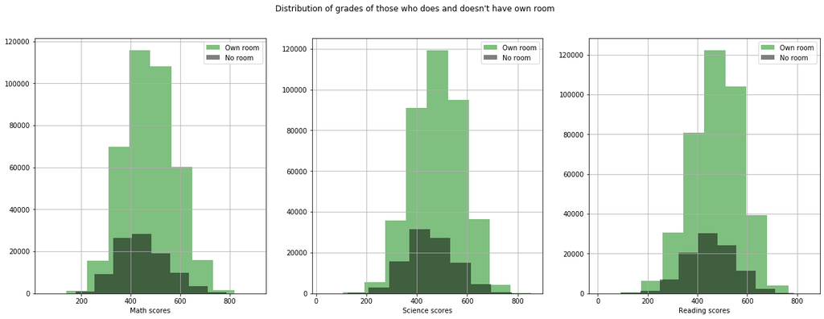

```python
# Possessions - own room

fig, ax = plt.subplots(nrows=1, ncols=3, figsize=(21,7))
df[df.ST26Q02 == 'Yes']['PV_MATH'].hist(ax=ax[0], alpha=.5, label='Own room', color='green')
df[df.ST26Q02 == 'No']['PV_MATH'].hist(ax=ax[0], alpha=.5, label='No room', color='black')
ax[0].set_xlabel('Math scores')
ax[0].legend()

df[df.ST26Q02 == 'Yes']['PV_SCIE'].hist(ax=ax[1], alpha=.5, label='Own room', color='green')
df[df.ST26Q02 == 'No']['PV_SCIE'].hist(ax=ax[1], alpha=.5, label='No room', color='black')
ax[1].set_xlabel('Science scores')
ax[1].legend()

df[df.ST26Q02 == 'Yes']['PV_READ'].hist(ax=ax[2], alpha=.5, label='Own room', color='green')
df[df.ST26Q02 == 'No']['PV_READ'].hist(ax=ax[2], alpha=.5, label='No room', color='black')
ax[2].set_xlabel('Reading scores')
ax[2].legend()

plt.suptitle('Distribution of grades of those who does and doesn\'t have own room')
plt.show()
```

About a quater of students doesn't have their own rooms. This affects their preparation to the exam. And as the result, the distribution of math and science scores of those students who don't have their own room is skewed to the right

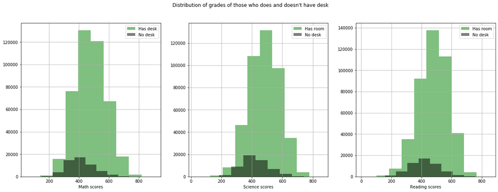

```python
# Possessions - has desk

fig, ax = plt.subplots(nrows=1, ncols=3, figsize=(21,7))
df[df.ST26Q01 == 'Yes']['PV_MATH'].hist(ax=ax[0], alpha=.5, label='Has desk', color='green')
df[df.ST26Q01 == 'No']['PV_MATH'].hist(ax=ax[0], alpha=.5, label='No desk', color='black')
ax[0].set_xlabel('Math scores')
ax[0].legend()

df[df.ST26Q01 == 'Yes']['PV_SCIE'].hist(ax=ax[1], alpha=.5, label='Has room', color='green')
df[df.ST26Q01 == 'No']['PV_SCIE'].hist(ax=ax[1], alpha=.5, label='No desk', color='black')
ax[1].set_xlabel('Science scores')
ax[1].legend()

df[df.ST26Q01 == 'Yes']['PV_READ'].hist(ax=ax[2], alpha=.5, label='Has room', color='green')
df[df.ST26Q01 == 'No']['PV_READ'].hist(ax=ax[2], alpha=.5, label='No desk', color='black')
ax[2].set_xlabel('Reading scores')
ax[2].legend()

plt.suptitle('Distribution of grades of those who does and doesn\'t have desk')
plt.show()
```

```python
df[df.ST26Q01 == 'No'].shape[0] / df.shape[0]
```

```
0.11132258130960473
```

11.1% of students don't have a desk, therefore, on average their math and science scores are lower than scores of students who has a table. Both, the distribution of reading scores of those who have and who doesn't have a desk ia normally distributed without any skewednes.

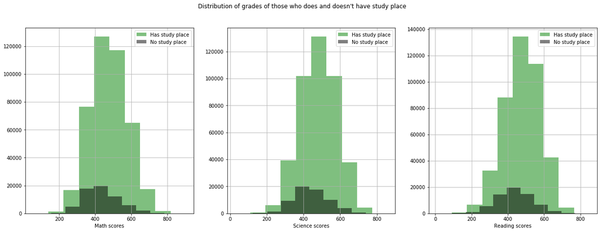

```python
# Possessions - has study place

fig, ax = plt.subplots(nrows=1, ncols=3, figsize=(21,7))
df[df.ST26Q03 == 'Yes']['PV_MATH'].hist(ax=ax[0], alpha=.5, label='Has study place', color='green')
df[df.ST26Q03 == 'No']['PV_MATH'].hist(ax=ax[0], alpha=.5, label='No study place', color='black')
ax[0].set_xlabel('Math scores')
ax[0].legend()

df[df.ST26Q03 == 'Yes']['PV_SCIE'].hist(ax=ax[1], alpha=.5, label='Has study place', color='green')
df[df.ST26Q03 == 'No']['PV_SCIE'].hist(ax=ax[1], alpha=.5, label='No study place', color='black')
ax[1].set_xlabel('Science scores')
ax[1].legend()

df[df.ST26Q03 == 'Yes']['PV_READ'].hist(ax=ax[2], alpha=.5, label='Has study place', color='green')
df[df.ST26Q03 == 'No']['PV_READ'].hist(ax=ax[2], alpha=.5, label='No study place', color='black')
ax[2].set_xlabel('Reading scores')
ax[2].legend()

plt.suptitle('Distribution of grades of those who does and doesn\'t have study place')
plt.show()
```

It's really difficult to prepare to the assessment if you dont have study place at home. As a result the distribution of scores of those students who don't have a study place on average receive lower scores on math and science.

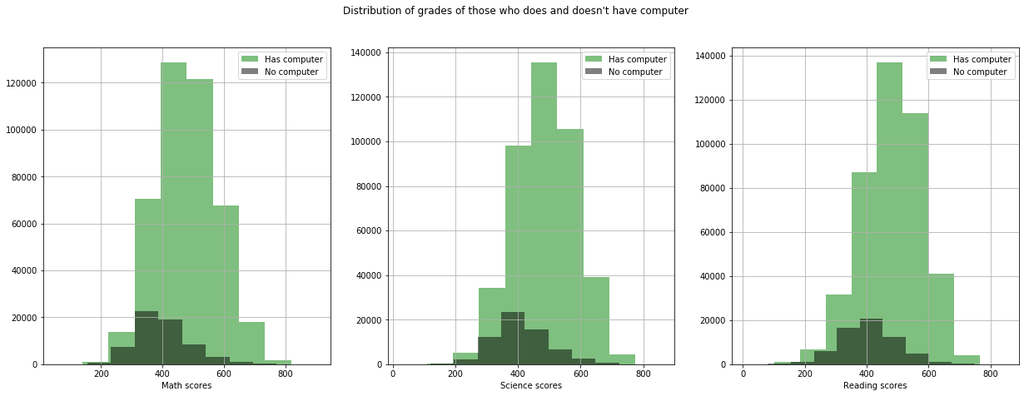

```python
# Possessions - has computer

fig, ax = plt.subplots(nrows=1, ncols=3, figsize=(21,7))
df[df.ST26Q04 == 'Yes']['PV_MATH'].hist(ax=ax[0], alpha=.5, label='Has computer', color='green')
df[df.ST26Q04 == 'No']['PV_MATH'].hist(ax=ax[0], alpha=.5, label='No computer', color='black')
ax[0].set_xlabel('Math scores')
ax[0].legend()

df[df.ST26Q04 == 'Yes']['PV_SCIE'].hist(ax=ax[1], alpha=.5, label='Has computer', color='green')
df[df.ST26Q04 == 'No']['PV_SCIE'].hist(ax=ax[1], alpha=.5, label='No computer', color='black')
ax[1].set_xlabel('Science scores')
ax[1].legend()

df[df.ST26Q04 == 'Yes']['PV_READ'].hist(ax=ax[2], alpha=.5, label='Has computer', color='green')
df[df.ST26Q04 == 'No']['PV_READ'].hist(ax=ax[2], alpha=.5, label='No computer', color='black')
ax[2].set_xlabel('Reading scores')
ax[2].legend()

plt.suptitle('Distribution of grades of those who does and doesn\'t have computer')
plt.show()
```

Absense of computer significantly complicates the preparation not only for the exam, but also for the homework. Because for example, not all students have large-screen tablets or smartphones that can partially replace a computer. As a result, the distribution of math scores is significantly skewed to the right. Distributions of reading and science scores are also slightly skewed to theright.

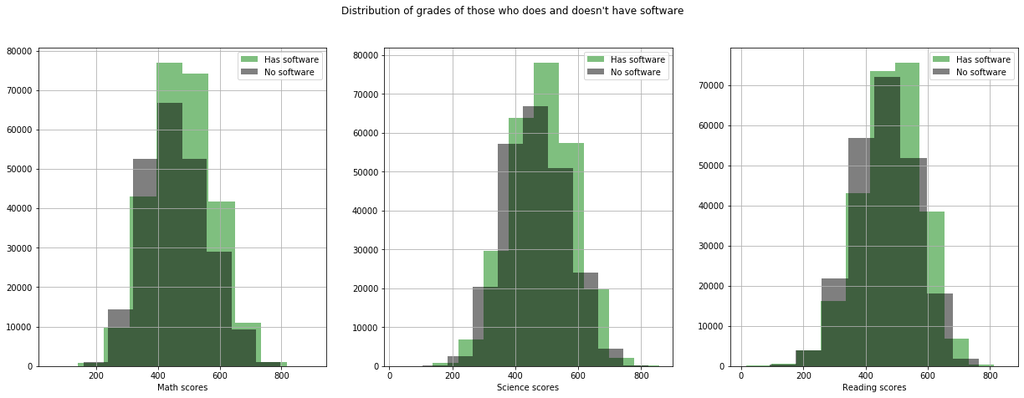

```python
# Possessions - has software

fig, ax = plt.subplots(nrows=1, ncols=3, figsize=(21,7))
df[df.ST26Q05 == 'Yes']['PV_MATH'].hist(ax=ax[0], alpha=.5, label='Has software', color='green')
df[df.ST26Q05 == 'No']['PV_MATH'].hist(ax=ax[0], alpha=.5, label='No software', color='black')
ax[0].set_xlabel('Math scores')
ax[0].legend()

df[df.ST26Q05 == 'Yes']['PV_SCIE'].hist(ax=ax[1], alpha=.5, label='Has software', color='green')
df[df.ST26Q05 == 'No']['PV_SCIE'].hist(ax=ax[1], alpha=.5, label='No software', color='black')
ax[1].set_xlabel('Science scores')
ax[1].legend()

df[df.ST26Q05 == 'Yes']['PV_READ'].hist(ax=ax[2], alpha=.5, label='Has software', color='green')
df[df.ST26Q05 == 'No']['PV_READ'].hist(ax=ax[2], alpha=.5, label='No software', color='black')
ax[2].set_xlabel('Reading scores')
ax[2].legend()

plt.suptitle('Distribution of grades of those who does and doesn\'t have software')
plt.show()
```

I can assume that the lack of software does not affect the distribution of grades in any way, since not all students pay money for software, thus, the lack of a computer worsens the average grade for the test more significantly.

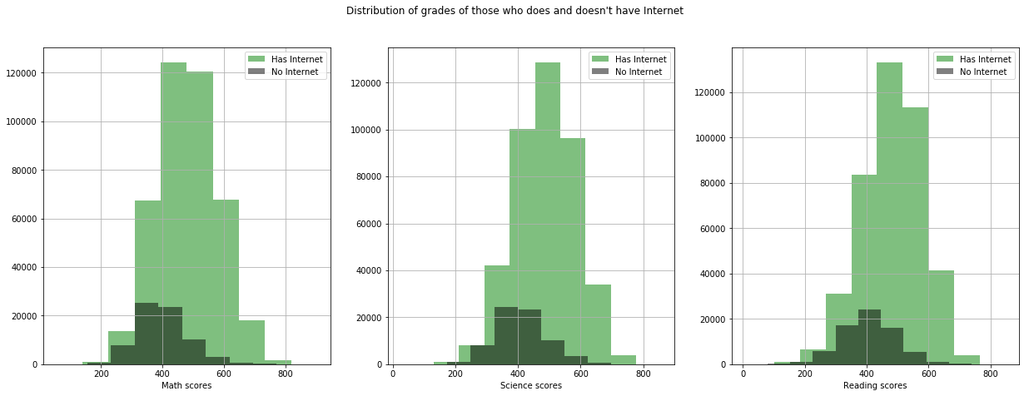

```python
# Possessions - has Internet

fig, ax = plt.subplots(nrows=1, ncols=3, figsize=(21,7))
df[df.ST26Q06 == 'Yes']['PV_MATH'].hist(ax=ax[0], alpha=.5, label='Has Internet', color='green')
df[df.ST26Q06 == 'No']['PV_MATH'].hist(ax=ax[0], alpha=.5, label='No Internet', color='black')
ax[0].set_xlabel('Math scores')
ax[0].legend()

df[df.ST26Q06 == 'Yes']['PV_SCIE'].hist(ax=ax[1], alpha=.5, label='Has Internet', color='green')
df[df.ST26Q06 == 'No']['PV_SCIE'].hist(ax=ax[1], alpha=.5, label='No Internet', color='black')
ax[1].set_xlabel('Science scores')
ax[1].legend()

df[df.ST26Q06 == 'Yes']['PV_READ'].hist(ax=ax[2], alpha=.5, label='Has Internet', color='green')
df[df.ST26Q06 == 'No']['PV_READ'].hist(ax=ax[2], alpha=.5, label='No Internet', color='black')
ax[2].set_xlabel('Reading scores')
ax[2].legend()

plt.suptitle('Distribution of grades of those who does and doesn\'t have Internet')
plt.show()
```

The lack of the Internet affects the distribution of grades in mathematics and science, since the process of obtaining the necessary information is either very slow or not at all. But it is worth noting that the presence of the Internet affects the distribution of reading grades in such a way that for those students who have the Internet, the opportunity to obtain additional information leads to a distortion of the distribution of grades to the left.

Summing up, I would like to say that for a student who prepares and takes the exam, any help, whether it be a computer, the Internet, a place for preparation, or his own team, positively correlates with higher grades in both mathematics and science and reading. This is a very interesting study that can be done by collecting additional missing data and adding information from other sources, for example, information on income and / or expenses of students' families.

#### 6. Whether total time learning and out of school lessons on math, science, and reading affect student performance?

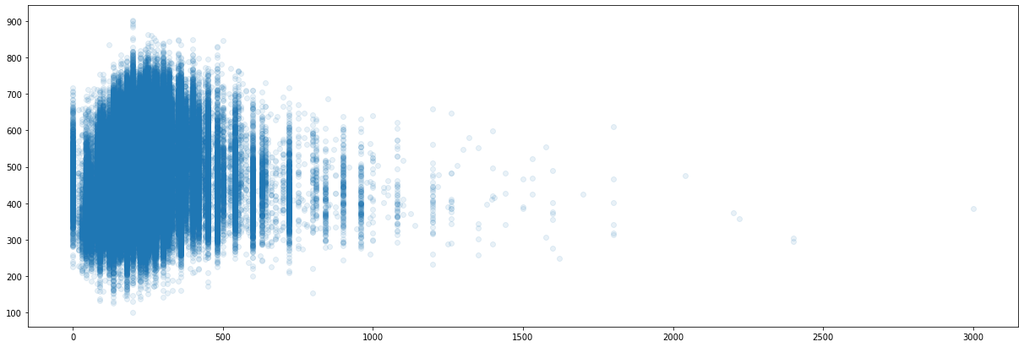

```python
plt.subplots(figsize=(21,7))
plt.scatter(df['MMINS'], df['PV_MATH'], alpha=.1, cmap='Blues_r')
plt.xlabel('')
plt.ylabel('')
plt.title('')
plt.show()
```

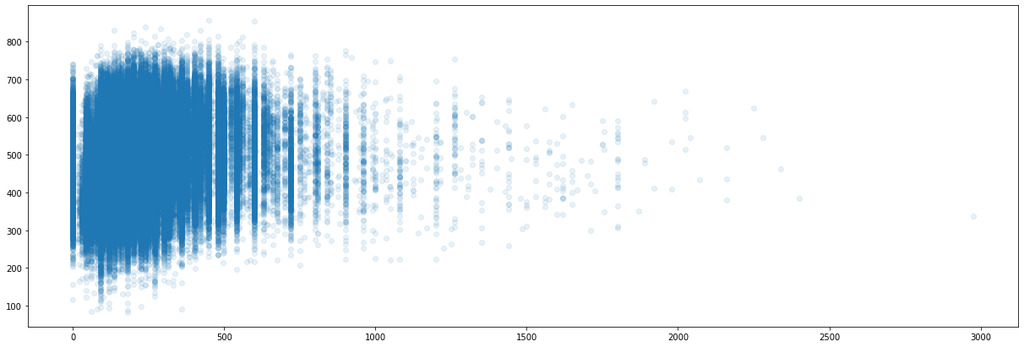

```python
plt.subplots(figsize=(21,7))
plt.scatter(df['SMINS'], df['PV_SCIE'], alpha=.1, cmap='Blues_r')
plt.xlabel('')
plt.ylabel('')
plt.title('')
plt.show()
```

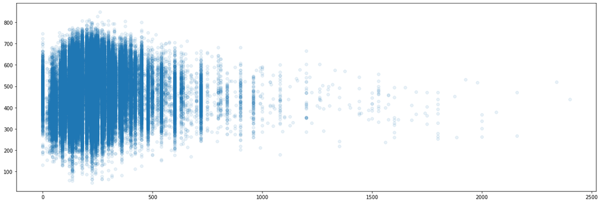

```python
plt.subplots(figsize=(21,7))
plt.scatter(df['LMINS'], df['PV_READ'], alpha=.1, cmap='Blues_r')
plt.xlabel('')
plt.ylabel('')
plt.title('')
plt.show()
```

```python
print(df[['MMINS', 'PV_MATH']].corr().iloc[0,1])
print(df[['SMINS', 'PV_SCIE']].corr().iloc[0,1])
print(df[['LMINS', 'PV_READ']].corr().iloc[0,1])
```

```
0.07118616777216413
0.1497322691619717
0.030070040120862448
```

Probably, the answer is obvious to the question whether there is a positive correlation between the number of hours of preparation for a particular subject and the grade for the exam after such preparation. But according to the schedules of preparing students for both mathematics and science and literature, one cannot say that there is a moderated relationship between this action and the result.  
In order to understand whether there really is no relationship between the preparation time for the exam and the grade for it. I calculated the Pearson correlation coefficient. And indeed the highest correlation coefficient is 15%.